# Clase 2 - Introducción a Python

## Sentencia IF

La sentencia `if` nos permite alterar el flujo de ejecución dependiendo de un valor lógico.

Es decir que si una condición se cumple (es `True`) entonces ejecutaremos una porción de código, pero si la condición no se cumple entonces ese código será saltado.

Es con el `if` donde encontramos una verdadera utilidad a los valores lógicos.

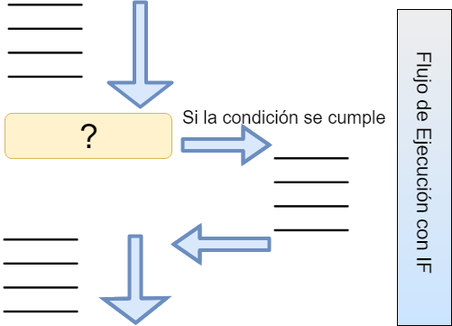

```python
from IPython.display import Image
Image(filename='./if1.png')
```

Veamos un ejemplo sencillo, en el que determinaremos si un número es par o impar y imprimimos de acuerdo a ello.

```python
x = 4
paridad = "es impar"

if x % 2 == 0:
    paridad = "es par"

print("El número %i %s" % (x, paridad) )
```

```
El número 4 es par
```

```python
x = 3
paridad = "es impar"

if x % 2 == 0:
    paridad = "es par"

print("El número %i %s" % (x, paridad) )
```

```
El número 3 es impar
```

Otro ejemplo:

Si tenemos un diccionario con edades de clientes que quieren ver una obra de teatro y queremos agregar una nueva llave llamada "Precio". La entrada cuesta 5000 colones para adultos (18 años en adelante), 4000 colones para personas entre los 15 y 18 años, y para las personas de 15 años o menores se cobra 3000 colones.

```python
clientes = {"Num Cliente": [1, 2, 3 , 4 , 5, 6, 7],
            "Edad": [23, 18, 28, 12, 33, 21, 17]}

precio = []

for edad in clientes["Edad"]:
    if edad >= 18:
        precio.append(5000)
    if 15 < edad < 18:
        precio.append(4000)
    if edad <= 15:
        precio.append(3000)

clientes["Precio"] = precio
clientes
```

```
{'Num Cliente': [1, 2, 3, 4, 5, 6, 7],
 'Edad': [23, 18, 28, 12, 33, 21, 17],
 'Precio': [5000, 5000, 5000, 3000, 5000, 5000, 4000]}
```

## Sentencia IF-ELSE

Ya vimos como usar `if` para ejecutar un código en caso de que se cumpla una condición, pero al `if` podemos agregar una sentencia llamada `else` para ejecutar un código en caso de que no se cumpla la condición.

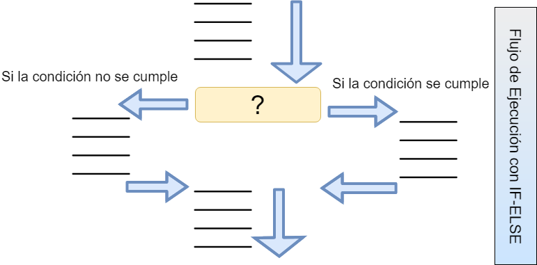

```python
from IPython.display import Image
Image(filename='./if2.png')
```

```python
lista = []
cadena = ""

if lista:
    cadena = "No esta vacia"
else:
    cadena = "La lista esta vacia"

print(cadena)
```

```
La lista esta vacia
```

```python
lista = [2, 3]
cadena = ""

if lista:
    cadena = "No esta vacia"
else:
    cadena = "La lista esta vacia"

print(cadena)
```

```
No esta vacia
```

```python
carros = ['audi', 'bmw', 'subaru', 'toyota']
for carro in carros:
    if carro == 'bmw':
        print(carro.upper())
    else:
        print(carro.title())
```

```
Audi
BMW
Subaru
Toyota
```

Repitamos nuestro ejercicio de las entradas de la obra de teatro, pero esta vez usando `else`.

Si tenemos un diccionario con edades de clientes que quieren ver una obra de teatro y queremos agregar una nueva llave llamada "Precio". La entrada cuesta 5000 colones para adultos (18 años en adelante), 4000 colones para personas entre los 15 y 18 años, y para las personas de 15 años o menores se cobra 3000 colones.

```python
clientes = {"Num Cliente": [1, 2, 3 , 4 , 5, 6, 7],
            "Edad": [23, 18, 28, 12, 33, 21, 17]}

precio = []

for edad in clientes["Edad"]:
    if edad >= 18:
        precio.append(5000)
    else:
        if 15 < edad < 18:
            precio.append(4000)
        else:
            precio.append(3000)

clientes["Precio"] = precio
clientes
```

```
{'Num Cliente': [1, 2, 3, 4, 5, 6, 7],
 'Edad': [23, 18, 28, 12, 33, 21, 17],
 'Precio': [5000, 5000, 5000, 3000, 5000, 5000, 4000]}
```

## Sentencia elif

La sentencia `elif` es una sentencia `else` a la cual le podemos aplicar una condición. Es básicamente un abreviación de:

**else**:

**if** < condición >:

Repitamos nuestro ejercicio de las entradas de la obra de teatro, pero esta vez usando `elif`.

Si tenemos un diccionario con edades de clientes que quieren ver una obra de teatro y queremos agregar una nueva llave llamada "Precio". La entrada cuesta 5000 colones para adultos (18 años en adelante), 4000 colones para personas entre los 15 y 18 años, y para las personas de 15 años o menores se cobra 3000 colones.

```python
clientes = {"Num Cliente": [1, 2, 3 , 4 , 5, 6, 7],
            "Edad": [23, 18, 28, 12, 33, 21, 17]}

precio = []

for edad in clientes["Edad"]:
    if edad >= 18:
        precio.append(5000)
    elif 15 < edad < 18:
        precio.append(4000)
    else:
        precio.append(3000)

clientes["Precio"] = precio
clientes
```

```
{'Num Cliente': [1, 2, 3, 4, 5, 6, 7],
 'Edad': [23, 18, 28, 12, 33, 21, 17],
 'Precio': [5000, 5000, 5000, 3000, 5000, 5000, 4000]}
```

```python
usuarios = {
  'ma_cespedes': {
     'nombre': 'maría',
     'apellido': 'céspedes',
     'lugar': 'alajuela',
   },
   'ma_alfaro': {
     'nombre': 'mario',
     'apellido': 'alfaro',
     'lugar': 'heredia',
   },
   'ju_rojas': {
     'nombre': 'julián',
     'apellido': 'rojas',
     'lugar': 'curridabat',
   },
}
```

```python
nombres_completos = {}

for usuario, info_usuario in usuarios.items():
    nombre = info_usuario['nombre'] + " " + info_usuario['apellido']
    if len(nombre) >= 14:
        nombre = info_usuario['nombre'][0] + " " + info_usuario['apellido']

    nombres_completos[usuario] = nombre.title()

nombres_completos
```

```
{'ma_cespedes': 'M Céspedes',
 'ma_alfaro': 'Mario Alfaro',
 'ju_rojas': 'Julián Rojas'}
```

## Ciclos while

Los ciclos `while` son muy parecidos a los ciclos `for`, pero los ciclos `while` permanecen en el ciclo mientras se cumpla una condición.

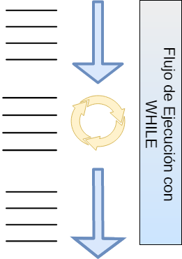

```python
from IPython.display import Image
Image(filename='./while.png')
```

```python
contador = 1
while contador <= 15:
    print(contador)
    contador = contador + 1

print("último valor de contador: %i" % contador)
```

```
1
2
3
4
5
6
7
8
9
10
11
12
13
14
15
último valor de contador: 16
```

**Nota**: Es muy importante que nos aseguremos que la condición va a llegar en algún momento a ser falsa, de lo contrario el `while` nuca va a terminar y el flujo de ejecución no va continuar, provocando que python no responda (Tendremos que reiniciar el kernel de python).

Cuando usamos ciclos podemos usar `break` para parar el ciclo y continuar el flujo de la ejecución.

```python
contador = 1
while contador <= 15:
    print(contador)
    if contador == 10:
        break
    contador = contador + 1

print("último valor de contador: %i" % contador)
```

```
1
2
3
4
5
6
7
8
9
10
último valor de contador: 10
```

También podemos usar `continue` para brincar a la siguiente iteración del ciclo. Es especialmente útil cuando cuando queremos omitir el cálculo de algún valor por algun motivo.

```python
contador = 0
while contador <= 15:
    contador = contador + 1
    if contador % 2 == 0:
        continue
    print(contador)

print("último valor de contador: %i" % contador)
```

```
1
3
5
7
9
11
13
15
último valor de contador: 16
```

## Entrada de Datos

En python para poder ingresar datos desde el teclado ocupamos usar `input` de la siguiente manera:

**input**(mensaje)

`mensaje` tiene que ser un string con un mensaje para el usuario, indicando que tiene que ingresar.

```python
mensaje = input("Escriba algo: ")
print(mensaje)
```

```
Escriba algo: hola
hola
```

```python
nombre = input("Escriba su nombre: ")
print("Hola, " + nombre + "!")
```

```
Escriba su nombre: Juan
Hola, Juan!
```

**Nota**: `input` nos retorna lo que ingresó el usuario como un string, incluso si ingresó un número.

```python
edad = input("Digite su edad: ")
print(type(edad))
edad = int(edad)
edad > 18
```

```
Digite su edad: 22
<class 'str'>
```

```
True
```

```python
numero = input("Digite un número para determinar si es par o impar: ")
numero = int(numero)
if numero % 2 == 0:
    print("\nEl número " + str(numero) + " es par.")
else:
    print("\nEl número " + str(numero) + " es impar.")
```

```
Digite un número para determinar si es par o impar: 24

El número 24 es par.
```

## Entrada de Datos y While

Cuando unimos el `while` con `input` podemos crear programas de consola.

```python
lectura = "\nDigite una número:"
lectura = lectura + "\n(Digite 'salir' para terminar el programa) "

mensaje = ""

while mensaje != 'salir':
    mensaje = input(lectura)
    if not mensaje.isnumeric():
        continue
    numero = int(mensaje)
    if numero % 2 == 0:
        print("\nEl número " + str(numero) + " es par.")
    else:
        print("\nEl número " + str(numero) + " es impar.")
```

```
Digite una número:
(Digite 'salir' para terminar el programa) hola

Digite una número:
(Digite 'salir' para terminar el programa) 45

El número 45 es impar.

Digite una número:
(Digite 'salir' para terminar el programa) 22

El número 22 es par.

Digite una número:
(Digite 'salir' para terminar el programa) salir
```

Otra manera de hacerlo es usando una bandera (una variable booleana) para indicar si tenemos que seguir en el ciclo o no.

```python
lectura = "\nDigite una número:"
lectura = lectura + "\n(Digite 'salir' para terminar el programa) "

seguir = True

while seguir:
    mensaje = input(lectura)
    if not mensaje.isnumeric():
        seguir = mensaje != "salir"
        continue
    numero = int(mensaje)
    if numero % 2 == 0:
        print("\nEl número " + str(numero) + " es par.")
    else:
        print("\nEl número " + str(numero) + " es impar.")
```

```
Digite una número:
(Digite 'salir' para terminar el programa) hola

Digite una número:
(Digite 'salir' para terminar el programa) 45

El número 45 es impar.

Digite una número:
(Digite 'salir' para terminar el programa) 22

El número 22 es par.

Digite una número:
(Digite 'salir' para terminar el programa) salir
```

También podemos usar un `break` para romper el ciclo y terminar el programa

```python
lectura = "\nDigite una número:"
lectura = lectura + "\n(Digite 'salir' para terminar el programa) "

while True: # Muy peligroso
    mensaje = input(lectura)
    if mensaje == "salir":
        break
    if not mensaje.isnumeric():
        continue
    numero = int(mensaje)
    if numero % 2 == 0:
        print("\nEl número " + str(numero) + " es par.")
    else:
        print("\nEl número " + str(numero) + " es impar.")
```

```
Digite una número:
(Digite 'salir' para terminar el programa) hola

Digite una número:
(Digite 'salir' para terminar el programa) 45

El número 45 es impar.

Digite una número:
(Digite 'salir' para terminar el programa) 22

El número 22 es par.

Digite una número:
(Digite 'salir' para terminar el programa) salir
```

## Funciones

Hasta el momento hemos usado muchas funciones pero no hemos hecho ninguna.

Las funciones son porciones de código que podemos ejecutar mediante un nombre, las funciones por lo general tienen parámetros que permiten variar algunos valores del código que se ejecuta dentro.

Hacer nuestras propias funciones es muy importante ya que nos permite reutilizar código y programar de forma más ordenada.

Para hacer una función debemos usar `def` de la siguiente manera:

**def** nombre_funcion(< parametro_1, parametro_2, … >):

< cuerpo de la función >

**Nota**: Los parámetros son opcional y podemos poner cuantos queramos.

```python
def sumar(x, y):
    z = x + y
    return z
```

El `return` indica que es lo que retorna la función.

```python
sumar(5, 6)
```

```
11
```

Por ejemplo si tenemos una programa de figuras geométricas y tenemos que usar la formula del area de un triángulo en múltiples lugares, lo mejor es poner la fórmula en una función y llamar a la función en donde se ocupe.

```python
def area_triangulo(base, altura):
    area = (base*altura)/2
    return(area)
```

```python
area_triangulo(3,5)
```

```
7.5
```

```python
area_triangulo(base=3, altura=5)
```

```
7.5
```

```python
area_triangulo(altura=5, base=3)
```

```
7.5
```

**Nota**: Si utilizamos los nombres de los parámetros para pasar los valores a la función el orden de los parámetros deja de importar.

## Parámetros por Defecto

Los parámetros por defecto nos permiten definir un valor para los parámetros en caso de que no se ingrese algún valor.

Por ejemplo, si en nuestra función `area_triangulo` no ingresamos alguno de los dos parámetros nos dará un error.

```python
def area_triangulo(base, altura):
    area = (base*altura)/2
    return(area)

area_triangulo(5)
```

```
---------------------------------------------------------------------------
TypeError                                 Traceback (most recent call last)
<ipython-input-61-f25c12f586b1> in <module>
      3     return(area)
      4
----> 5 area_triangulo(5)

TypeError: area_triangulo() missing 1 required positional argument: 'altura'
```

Esto se puede solucionar utilizando parámetros por defecto.

```python
def area_triangulo(base = 1, altura = 1):
    area = (base*altura)/2
    return(area)

area_triangulo(5)
```

```
2.5
```

Los parámetros por defecto pueden ser engañosos cuando los parámetros son tipos de datos mutables.

```python
def agregar_suma(x, y, lista = []):
    lista.append(x + y)
    return lista
```

```python
mi_lista = agregar_suma(5, 2)
mi_lista = agregar_suma(10, 10, mi_lista)
mi_lista
```

```
[7, 20]
```

Hasta el momento todo bien, pero si quiero volver a usar el parámetro por defecto sucede lo siguiente:

```python
mi_lista2 = agregar_suma(20, 80)
mi_lista2 = agregar_suma(100, 10, mi_lista2)
mi_lista2
```

```
[7, 20, 100, 110]
```

Lo correcto sería:

```python
def agregar_suma(x, y, lista = None):
    if lista == None:
        lista = []
    lista.append(x + y)
    return lista
```

```python
mi_lista = agregar_suma(5, 2)
mi_lista = agregar_suma(10, 10, mi_lista)
mi_lista
```

```
[7, 20]
```

```python
mi_lista2 = agregar_suma(20, 80)
mi_lista2 = agregar_suma(100, 10, mi_lista2)
mi_lista2
```

```
[100, 110]
```

## Retornando Múltiples Valores

No existe límite en lo que podemos retornar de una función mientras solo sea un único objeto, por lo que si queremos retornar múltiples valores tendremos que retornar una tupla, lista o diccionario.

Si quisiéramos retornar el área y el perímetro de un cuadrado, según uno de sus lados:

```python
def cuadrado_valores(lado):
    respuesta = {}
    respuesta["area"] = lado ** 2
    respuesta["perimetro"] = lado*4
    return respuesta
```

```python
cuadrado_valores(5)
```

```
{'area': 25, 'perimetro': 20}
```

```python
cuadrado_valores(16)
```

```
{'area': 256, 'perimetro': 64}
```

La siguiente función recibe un DataFrame (DF) y retorna en un diccionario el valor mímimo, el máximo, la cantidad de ceros y la cantidad de números pares que contiene el dataFrame:

```python
def valores(DF):
    n, m = DF.shape
    minimo = DF.iloc[0,0]
    maximo = minimo
    total_ceros = 0
    total_pares = 0
    for i in range(n):
        for j in range(m):
            if DF.iloc[i,j] > maximo:
                maximo = DF.iloc[i,j]
            if DF.iloc[i,j] < minimo:
                minimo = DF.iloc[i,j]
            if DF.iloc[i,j] == 0:
                total_ceros = total_ceros+1
            if DF.iloc[i,j] % 2 == 0:
                total_pares = total_pares+1

    respuesta = {'Maximo' : maximo, 'Mimimo' : minimo,
                 'Total_Ceros' : total_ceros, 'Pares' : total_pares}
    return respuesta
```

```python
datos_est = pd.read_csv('ejemplo_estudiantes.csv', delimiter = ';', decimal = ",",
                        header = 0, index_col = 0)
datos_est
```

|  | Matematicas | Ciencias | Espanol | Historia | EdFisica |
| --- | --- | --- | --- | --- | --- |
| Lucia | 7.0 | 6.5 | 9.2 | 8.6 | 8.0 |
| Pedro | 7.5 | 9.4 | 7.3 | 7.0 | 7.0 |
| Ines | 7.6 | 9.2 | 8.0 | 8.0 | 7.5 |
| Luis | 5.0 | 6.5 | 6.5 | 7.0 | 9.0 |
| Andres | 6.0 | 6.0 | 7.8 | 8.9 | 7.3 |
| Ana | 7.8 | 9.6 | 7.7 | 8.0 | 6.5 |
| Carlos | 6.3 | 6.4 | 8.2 | 9.0 | 7.2 |
| Jose | 7.9 | 9.7 | 7.5 | 8.0 | 6.0 |
| Sonia | 6.0 | 6.0 | 6.5 | 5.5 | 8.7 |
| Maria | 6.8 | 7.2 | 8.7 | 9.0 | 7.0 |

```python
valores(datos_est)
```

```
{'Maximo': 9.7, 'Mimimo': 5.0, 'Total_Ceros': 0, 'Pares': 10}
```

La siguiente función recibe un DataFrame (DF) y un número de columna (nc) y retorna en un diccionario el nombre de la variable correspondiente al número de columna, la media, la mediana, la desviación estándar,la varianza, el máximo y el mínimo:

```python
import numpy as np

def estadisticas(DF,nc):
    media = np.mean(DF.iloc[:,nc])
    mediana = np.median(DF.iloc[:,nc])
    deviacion = np.std(DF.iloc[:,nc])
    varianza = np.var(DF.iloc[:,nc])
    maximo = np.max(DF.iloc[:,nc])
    minimo = np.min(DF.iloc[:,nc])
    return {'Variable' : DF.columns.values[nc],
            'Media' : media,
            'Mediana' : mediana,
            'DesEst' : deviacion,
            'Varianza' : varianza,
            'Maximo' : maximo,
            'Minimo' : minimo}
```

```python
estadisticas(datos_est,1)
```

```
{'Variable': 'Ciencias',
 'Media': 7.650000000000001,
 'Mediana': 6.85,
 'DesEst': 1.5272524349301262,
 'Varianza': 2.332499999999999,
 'Maximo': 9.7,
 'Minimo': 6.0}
```

## Funciones con n Parámetros

En algunas ocasiones puede que queramos usar una cantidad indefinida de parámetros para hacer nuestras funciones más generales.

Por ejemplo, hagamos que nuestra función `sumar` funciones para n parámetros.

```python
def sumar(*numeros):
    suma = 0
    for valor in numeros:
        suma = suma + valor
    return suma
```

```python
sumar(2,3,4)
```

```
9
```

```python
sumar(2,3,4,5,6,234,123)
```

```
377
```

## Módulos

Los módulos son archivos con extensión .py los cuales podemos llamar para usar las funciones o clases que estén definidas en el archivo.

Ya hemos visto como importar un modulo, pero las formas de hacerlo son variadas:

- **import** nombre_modulo
- **from** nombre_modulo **import** nombre_funcion
- **from** nombre_modulo **import** funcion_0, funcion_1, funcion_2

También podemos agregar un alias a un paquete para hacer más fácil su uso:

- **import** nombre_modulo **as** nuevo_nombre

```python
import ejemplo_modulo as em
```

```python
res = em.maximo(datos_est)
res
```

```
9.7
```

```python
res = em.valores(datos_est)
res
```

```
{'Maximo': 9.7, 'Mimimo': 5.0, 'Total_Ceros': 0, 'Pares': 10}
```

```python
res = em.estadisticas(datos_est, 1)
res
```

```
{'Variable': 'Ciencias',
 'Media': 7.650000000000001,
 'Mediana': 6.85,
 'DesEst': 1.5272524349301262,
 'Varianza': 2.332499999999999,
 'Maximo': 9.7,
 'Minimo': 6.0}
```

[figure not shown]

```python
from IPython.display import Image
Image(filename='./logo_python.png')
```